# Ass 4

Nathanael Reese

2023-04-23

## Completed 10/10

### Task 1

```r
library(LaF)
```

```r
# Function that samples the file
sample1 <- function(file, n) {
  lf <- laf_open(detect_dm_csv(file, sep = ",", header = TRUE, factor_fraction = -1))
  return(read_lines(lf, sample(1:nrow(lf), n)))
}
```

**sample**

```r
sample <- sample1("NZBIRDS.csv", 35)
```

#### (b)

```r
mp <- c(-1,1)
mean(sample$Body.Mass) + mp*qt(1-.05,34)*sd(sample$Body.Mass)/sqrt(35)
```

```
## [1]  6275.105 36066.495
```

#### (f)

```r
n1 = 38 # total extinct
n2 = 78 # total not extinct

p1hat = 21 / n1
q1hat = 1 - p1hat
p2hat = 7 / n2
q2hat = 1 - p2hat

mp = c(-1,1)
ci <- (p1hat - p2hat) + mp * qnorm(1-.05/2,0,1)*sqrt((p1hat*q1hat/n1) + (p2hat*q2hat/n2))
ci
```

```
## [1] 0.2925475 0.6332285
```

### Task 2

```r
s1 <- rnorm(100, mean = 1312, sd = 422)
s2<- rnorm(47, mean = 1352, sd = 271)

t.test(s1,s2, conf.level = .95)
```

```
##
##  Welch Two Sample t-test
##
## data:  s1 and s2
## t = 1.0054, df = 126.3, p-value = 0.3166
## alternative hypothesis: true difference in means is not equal to 0
## 95 percent confidence interval:
##  -57.38744 175.91696
## sample estimates:
## mean of x mean of y
##  1409.409  1350.145
```

### Task 3

#### a)

Given $Y$ ~ $N(0, \sigma^2)$

The standard Normal Variate

$Z = \frac{Y-0}{\sigma}$ ~ $N(0,1)$

-> $Z^2$ ~ $\chi^2_{(1)df}$

-> $(\frac{Y}{\sigma})^2$ ~ $\chi^2_{(1)df}$

-> $\frac{Y^2}{\sigma^2}$ ~ $\chi^2_{(1)df}$

Since square of standard Normal variate follows chisqare distribution with 1 df

#### b)

**95% confidence interval** *Test Stat* $\chi^2 = \frac{Y^2}{\sigma^2}$ ~ $\chi^2_{(1)df}$

if two tail test

$P(\chi^2_{(\alpha/2, n-1df)} < \frac{Y^2}{\sigma^2} < \chi^2_{(1-\alpha, n-1df)}) = (1-\alpha)100$%

$P(\frac{1}{\chi^2_{(\alpha/2, n-1df)}} < \frac{\sigma^2}{Y^2} < \frac{Y^2}{\chi^2_{(1-\alpha, n-1df)}}) = (1-\alpha)100$%

$P(\frac{Y^2}{\chi^2_{(\alpha/2, n-1df)}} < \sigma^2 < \frac{1}{\chi^2_{(1-\alpha, n-1df)}}) = (1-\alpha)100$%

Lower Limit of $\sigma^2$ is L = $\frac{Y^2}{\chi^2_{(\alpha/2, n-1df)}}$

Upper Limit of $\sigma^2$ is U = $\frac{1}{\chi^2_{(1-\alpha, n-1df)}}$

### Task 4

#### (a)

The null hypothesis is that $\mu = 2$ and the alternative hypothesis is that $\mu \neq2$

#### (b)

T: -1.02 and the P-value:0.322

#### (c)

The reject region is |T| < 2.1262

#### (d)

Since the pvalue is greater than alpha, we accept the null hypotehsis

### Task 5

#### a)

Sample size is n=25

Pop. Mean is $\mu$ = 15

Sample mean is $\bar{x}$ sample sd is s = 12.9637

lets test $H_0$: $\mu = 15$ vs $H_1$: $\mu \neq 15$

and use ${\bar{x}-\mu}/{S}/{\sqrt{n}}$ = -0.1867

$\alpha = 0.10$ and P-val is 0.854, so result is not significant so we can say that the sample is representative of all Wisconsin lakes for the DOC

#### b)

if mean is 14 test does not indicate any significant difference

### Task 6

```r
data <- read.csv("ORCHARD.csv")
foggy <- data[data$CONDITION == "FOG",]
cloudyClear <- data[data$CONDITION != "FOG",]

t.test(data$CONDITION == "FOG",data$CONDITION != "FOG", mu= 0, conf.level = .95)
```

```
##
##  Welch Two Sample t-test
##
## data:  data$CONDITION == "FOG" and data$CONDITION != "FOG"
## t = 2.0412, df = 24, p-value = 0.05237
## alternative hypothesis: true difference in means is not equal to 0
## 95 percent confidence interval:
##  -0.004269104  0.773499874
## sample estimates:
## mean of x mean of y
## 0.6923077 0.3076923
```

We see the pvalue is > than alpha, thus we accept $H_0:\mu_1-\mu_2 = 0$

### Task 7

#### a)

```r
turbine <- read.csv("GASTURBINE.csv")

traditional <- turbine[turbine$ENGINE == "Traditional",]


aeroder <- turbine[turbine$ENGINE == "Aeroderiv",]

var.test(traditional$HEATRATE, aeroder$HEATRATE,conf.level = .95, var.equal=T)
```

```
##
##  F test to compare two variances
##
## data:  traditional$HEATRATE and aeroder$HEATRATE
## F = 0.23272, num df = 38, denom df = 6, p-value = 0.004234
## alternative hypothesis: true ratio of variances is not equal to 1
## 95 percent confidence interval:
##  0.04635082 0.64308536
## sample estimates:
## ratio of variances
##          0.2327207
```

#### b)

```r
advanced <-  turbine[turbine$ENGINE == "Advanced",]

var.test(advanced$HEATRATE, aeroder$HEATRATE,conf.level = .95, var.equal=T)
```

```
##
##  F test to compare two variances
##
## data:  advanced$HEATRATE and aeroder$HEATRATE
## F = 0.057974, num df = 20, denom df = 6, p-value = 1.192e-06
## alternative hypothesis: true ratio of variances is not equal to 1
## 95 percent confidence interval:
##  0.0112170 0.1813622
## sample estimates:
## ratio of variances
##         0.05797393
```

### Task 8

dry steppe - n = 5, (3, 3, 52, 7, 5)

gobi - n = 6, (49, 5, 4, 4, 5, 4)

for $s^2_1 = 454$

for $s^2_2 = 331.76667$

#### a)

$$H_0 = \frac{\sigma^2_1}{\sigma^2_2} = 1\\
H_a = \frac{\sigma^2_1}{\sigma^2_2} \neq 1$$

#### b)

the ratio f = s21/s22 is a value of the F-distribution with v1 = 5 − 1 = 4 and v2 = 6− 1 = 5degrees of freedom. Therefore, the critical regions

f = 454/331.76667 = 1.3684

#### c)

rejection region is f > $f_{0.025}$(4,5) or f < $f_{0.975}$(4,5)

f > 7.39 or f < 0.11

#### d)

p-value = 0.64

#### e)

since 1.3684 does not lie in critical region ,we can not reject the hypothesis.

**we conclude that there is insufficient evidence that the variances differ.**

#### f)

independent random samples from normal population.

### Task 9

The null and alternative hypotheses are: $H_0: \mu_d = 0$ and $H_1: \mu_d \neq 0$

assume equal variances

```r
stdata<- read.csv("THRUPUT.csv")

t.test(stdata$HUMAN, stdata$AUTO, mu=0, paired = T)
```

```
##
##  Paired t-test
##
## data:  stdata$HUMAN and stdata$AUTO
## t = -2.629, df = 7, p-value = 0.03396
## alternative hypothesis: true mean difference is not equal to 0
## 95 percent confidence interval:
##  -61.850346  -3.274654
## sample estimates:
## mean difference
##        -32.5625
```

### Task 10

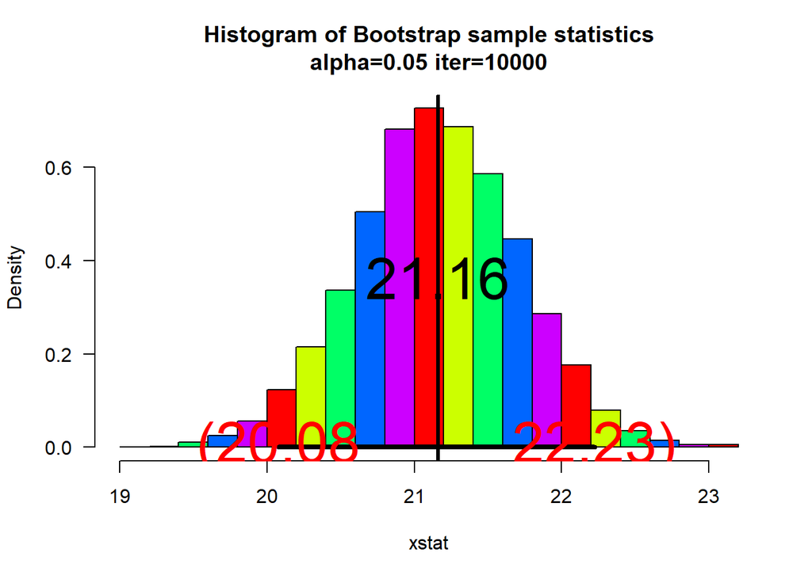

```
## $ci
##     2.5%    97.5%
## 20.07910 22.22545
##
## $fun
## [1] "mean"
##
## $x
##  [1] 23.195 20.399 19.898 19.865 30.014 18.821 21.232 18.313 23.574 21.047
## [11] 21.535 21.336 17.695 18.497 14.274 14.664 22.593 18.963 25.515 25.019
## [21] 22.053 22.871 23.006 23.829 19.038 21.735 21.461 21.659 21.703 21.049
##
## $t
## function (x)
## UseMethod("t")
## <bytecode: 0x000001b122132a10>
## <environment: namespace:base>
```

```r
## sample function
set.seed(35) # This will give everyone the same sample
sam=round(rnorm(30,mean=20,sd=3),3)



########### bootstrap function ##################

myboot<-function(iter=10000,x,fun="mean",alpha=0.05,...){  #Notice where the ... is repeated in the code
n=length(x)   #sample size

y=sample(x,n*iter,replace=TRUE)
rs.mat=matrix(y,nr=n,nc=iter,byrow=TRUE)
xstat=apply(rs.mat,2,fun) # xstat is a vector and will have iter values in it
ci=quantile(xstat,c(alpha/2,1-alpha/2))# Nice way to form a confidence interval
# A histogram follows
# The object para will contain the parameters used to make the histogram
para=hist(xstat,freq=FALSE,las=1,
main=paste("Histogram of Bootstrap sample statistics","\n","alpha=",alpha," iter=",iter,sep=""),
...,col = rainbow(5))

#mat will be a matrix that contains the data, this is done so that I can use apply()
mat=matrix(x,nr=length(x),nc=1,byrow=TRUE)

#pte is the point estimate
#This uses whatever fun is
pte=apply(mat,2,fun)
abline(v=pte,lwd=3,col="Black")# Vertical line
segments(ci[1],0,ci[2],0,lwd=4)      #Make the segment for the ci
text(ci[1],0,paste("(",round(ci[1],2),sep=""),col="Red",cex=3)
text(ci[2],0,paste(round(ci[2],2),")",sep=""),col="Red",cex=3)

# plot the point estimate 1/2 way up the density
text(pte,max(para$density)/2,round(pte,2),cex=3)

return(list(ci=ci,fun=fun,x=x, t=t))# Some output to use if necessary
}

myboot(x=sam)
```